# Análisis ARIMA con Vision UI - Estilo Moderno

Series Temporales y Pronósticos

04 de diciembre de 2025

# 1 Análisis y Pronóstico de Series Temporales con ARIMA

Modelado de series temporales usando modelos ARIMA | Universidad del Valle

# 2 Introducción

## 2.1 Relevancia del análisis

Las series temporales son omnipresentes en campos como la economía, finanzas, meteorología y ciencias sociales. El modelado ARIMA permite:

- **Identificar patrones** históricos en los datos
- **Detectar tendencias** de largo plazo
- **Modelar estacionalidad** cuando existe
- **Realizar pronósticos** con bases estadísticas sólidas
- **Apoyar decisiones** basadas en evidencia cuantitativa

```r
library(tidyverse)
library(forecast)
library(tseries)
library(ggplot2)
library(knitr)
library(kableExtra)
library(plotly)
library(lubridate)
```

```r
# Tema personalizado para gráficos Vision UI
theme_vision <- function() {
  theme_minimal() +
  theme(
    plot.background = element_rect(fill = "#0F1535", color = NA),
    panel.background = element_rect(fill = "#1a1f37", color = NA),
    panel.grid.major = element_line(color = "#2a3152", size = 0.3),
    panel.grid.minor = element_line(color = "#1f2540", size = 0.2),
    text = element_text(color = "#e0e6ed", family = "sans"),
    axis.text = element_text(color = "#A0AEC0"),
    axis.title = element_text(color = "#4FD1C5", face = "bold", size = 12),
    plot.title = element_text(color = "#4FD1C5", face = "bold", size = 14, hjust = 0.5),
    plot.subtitle = element_text(color = "#e0e6ed", size = 11, hjust = 0.5),
    legend.background = element_rect(fill = "#1a1f37", color = "#4FD1C5"),
    legend.text = element_text(color = "#e0e6ed"),
    legend.title = element_text(color = "#4FD1C5", face = "bold")
  )
}

theme_set(theme_vision())
```

# 3 Metodología

## 3.1 Conceptos fundamentales

### 3.1.1 Serie de Tiempo

Una **serie de tiempo** es una secuencia de observaciones de una variable medidas en intervalos regulares. Matemáticamente:

$$Y_t = T_t + S_t + C_t + I_t$$

Donde: - $Y_t$: Valor observado en tiempo $t$ - $T_t$: Componente de **tendencia** - $S_t$: Componente de **estacionalidad** - $C_t$: Componente **cíclico** - $I_t$: Componente **irregular** (ruido blanco)

### 3.1.2 Modelo ARIMA

ARIMA(p, d, q) combina tres componentes:

**AR(p) - Autorregresivo:**
$$Y_t = c + \phi_1 Y_{t-1} + \cdots + \phi_p
Y_{t-p} + \epsilon_t$$

**I(d) - Integrado:** Número de diferencias para estacionariedad

**MA(q) - Media Móvil:**
$$Y_t = c + \epsilon_t + \theta_1 \epsilon_{t-1} +
\cdots + \theta_q \epsilon_{t-q}$$

✅ **Ventajas de ARIMA:** Flexible, ampliamente validado en economía y finanzas, fundamentado en teoría estadística robusta.

# 4 Descripción de Datos

## 4.1 Preparación y carga

```r
# Crear datos simulados (REEMPLAZA CON TUS DATOS REALES)
set.seed(42)
n <- 120  # 10 años de datos mensuales
tiempo <- seq(as.Date("2014-01-01"), by = "month", length.out = n)

tendencia <- seq(100, 180, length.out = n)
estacionalidad <- 15 * sin(2 * pi * (1:n) / 12)
ruido <- rnorm(n, 0, 5)

datos <- data.frame(
  fecha = tiempo,
  valor = tendencia + estacionalidad + ruido
)

serie_ts <- ts(datos$valor,
               start = c(2014, 1),
               frequency = 12)

cat("Dimensión de datos:", length(serie_ts), "observaciones\n")
```

```
## Dimensión de datos: 120 observaciones
```

```r
cat("Período:", format(tiempo[1], "%Y-%m"), "a", format(tiempo[n], "%Y-%m"), "\n")
```

```
## Período: 2014-01 a 2023-12
```

## 4.2 Estadísticas descriptivas

```r
stats_df <- data.frame(
  Métrica = c("Media", "Mediana", "Desv. Estándar",
              "Mínimo", "Máximo", "Rango", "Coef. Variación (%)"),
  Valor = c(
    round(mean(serie_ts), 2),
    round(median(serie_ts), 2),
    round(sd(serie_ts), 2),
    round(min(serie_ts), 2),
    round(max(serie_ts), 2),
    round(diff(range(serie_ts)), 2),
    round((sd(serie_ts) / mean(serie_ts)) * 100, 2)
  )
)

kable(stats_df,
      format = "html",
      caption = "Estadísticas Descriptivas") %>%
  kable_styling(
    bootstrap_options = c("striped", "hover"),
    full_width = FALSE,
    position = "center"
  )
```

Estadísticas Descriptivas

| Métrica | Valor |
| --- | --- |
| Media | 140.15 |
| Mediana | 139.12 |
| Desv. Estándar | 25.18 |
| Mínimo | 91.24 |
| Máximo | 188.82 |
| Rango | 97.58 |
| Coef. Variación (%) | 17.97 |

## 4.3 Visualización inicial

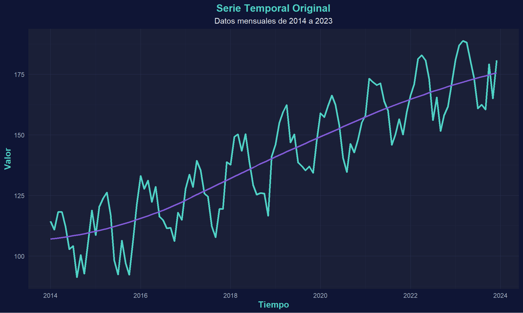

```r
autoplot(serie_ts) +
  labs(
    title = "Serie Temporal Original",
    subtitle = "Datos mensuales de 2014 a 2023",
    x = "Tiempo",
    y = "Valor"
  ) +
  theme_vision() +
  geom_line(color = "#4FD1C5", size = 1.1) +
  geom_smooth(color = "#805AD5", alpha = 0.2, se = FALSE)
```

# 5 Análisis Exploratorio

## 5.1 Descomposición de la serie

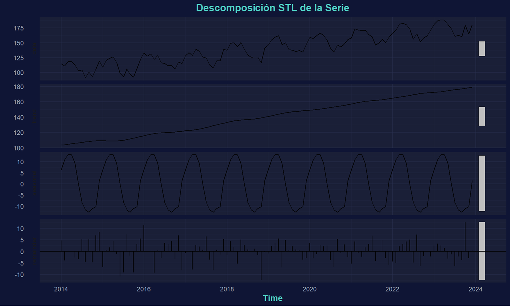

```r
descomp <- stl(serie_ts, s.window = "periodic")

autoplot(descomp) +
  labs(title = "Descomposición STL de la Serie") +
  theme_vision()
```

## 5.2 Análisis de componentes

```r
tendencia_comp <- descomp$time.series[, "trend"]
estacional_comp <- descomp$time.series[, "seasonal"]
residuos_comp <- descomp$time.series[, "remainder"]

# Calcular fuerzas
fuerza_estacional <- 1 - var(residuos_comp) / var(estacional_comp + residuos_comp)
fuerza_tendencia <- 1 - var(residuos_comp) / var(tendencia_comp + residuos_comp)

cat("📊 ANÁLISIS DE COMPONENTES\n")
```

```
## 📊 ANÁLISIS DE COMPONENTES
```

```r
cat("===========================\n\n")
cat("Fuerza de Estacionalidad: ", round(fuerza_estacional, 4), "\n")
```

```
## Fuerza de Estacionalidad:  0.8275
```

```r
cat("Fuerza de Tendencia: ", round(fuerza_tendencia, 4), "\n\n")
```

```
## Fuerza de Tendencia:  0.9615
```

```r
if (fuerza_estacional > 0.6) {
  cat("✓ Estacionalidad FUERTE detectada\n")
} else {
  cat("✗ Estacionalidad débil o moderada\n")
}
```

```
## ✓ Estacionalidad FUERTE detectada
```

```r
if (fuerza_tendencia > 0.6) {
  cat("✓ Tendencia FUERTE detectada\n")
} else {
  cat("✗ Tendencia débil o moderada\n")
}
```

```
## ✓ Tendencia FUERTE detectada
```

# 6 Verificación de Estacionariedad

📌 **¿Por qué es importante?**  
ARIMA requiere series estacionarias. Si la serie no es estacionaria, necesitamos diferenciarla (parámetro d > 0).

## 6.1 Tests de estacionariedad

```r
# Test ADF
adf <- adf.test(serie_ts)
cat("🔍 TEST AUGMENTED DICKEY-FULLER (ADF)\n")
```

```
## 🔍 TEST AUGMENTED DICKEY-FULLER (ADF)
```

```r
cat("=====================================\n")
cat("Estadístico: ", round(adf$statistic, 4), "\n")
```

```
## Estadístico:  -9.9307
```

```r
cat("p-valor: ", round(adf$p.value, 4), "\n")
```

```
## p-valor:  0.01
```

```r
if (adf$p.value < 0.05) {
  cat("✓ RECHAZA hipótesis nula: Serie es ESTACIONARIA\n\n")
} else {
  cat("✗ NO rechaza hipótesis nula: Serie es NO ESTACIONARIA\n\n")
}
```

```
## ✓ RECHAZA hipótesis nula: Serie es ESTACIONARIA
```

```r
# Test KPSS
kpss <- kpss.test(serie_ts)
cat("🔍 TEST KPSS\n")
```

```
## 🔍 TEST KPSS
```

```r
cat("===========\n")
cat("Estadístico: ", round(kpss$statistic, 4), "\n")
```

```
## Estadístico:  2.2245
```

```r
cat("p-valor: ", round(kpss$p.value, 4), "\n")
```

```
## p-valor:  0.01
```

```r
if (kpss$p.value > 0.05) {
  cat("✓ NO rechaza hipótesis nula: Serie es ESTACIONARIA\n")
} else {
  cat("✗ Rechaza hipótesis nula: Serie es NO ESTACIONARIA\n")
}
```

```
## ✗ Rechaza hipótesis nula: Serie es NO ESTACIONARIA
```

## 6.2 ACF y PACF

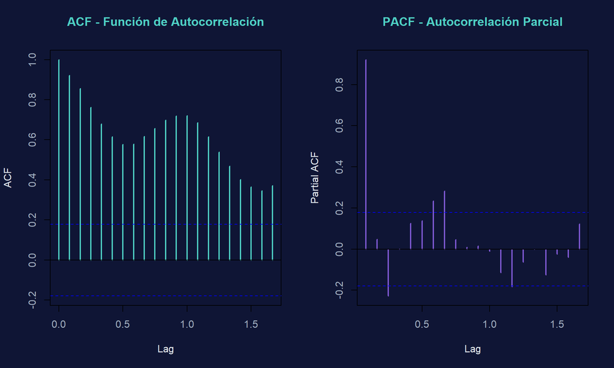

```r
par(mfrow = c(1, 2), bg = "#0F1535", col.main = "#4FD1C5",
    col.lab = "#e0e6ed", col.axis = "#A0AEC0")

acf(serie_ts, main = "ACF - Función de Autocorrelación",
    col = "#4FD1C5", lwd = 2)
pacf(serie_ts, main = "PACF - Autocorrelación Parcial",
     col = "#805AD5", lwd = 2)
```

```r
par(mfrow = c(1, 1))
```

# 7 Selección y Ajuste de Modelo

## 7.1 Auto ARIMA

```r
modelo_auto <- auto.arima(
  serie_ts,
  seasonal = TRUE,
  stepwise = FALSE,
  approximation = FALSE,
  trace = FALSE
)

cat("🎯 MODELO ARIMA AUTOMÁTICO\n")
```

```
## 🎯 MODELO ARIMA AUTOMÁTICO
```

```r
cat("===========================\n\n")
print(summary(modelo_auto))
```

```
## Series: serie_ts
## ARIMA(0,0,0)(0,1,1)[12] with drift
##
## Coefficients:
##          sma1   drift
##       -0.8295  0.6665
## s.e.   0.1231  0.0156
##
## sigma^2 = 31.19:  log likelihood = -344.85
## AIC=695.71   AICc=695.94   BIC=703.75
##
## Training set error measures:
##                      ME     RMSE      MAE        MPE     MAPE      MASE
## Training set -0.4093527 5.249288 3.975184 -0.5343785 2.957152 0.4499559
##                    ACF1
## Training set 0.02731073
```